# Hospital Emergency Room Efficiency Data Analysis

Author: Sana Siddiqui, MD

# Introduction

Hospital emergency rooms (ERs) are fast paced, high turnover environments that demand maximum efficiency to ensure timely patient care. In order to consistently meet this goal, patient surveys are an excellent tool to gain insight into patient satisfaction with the care provided in ERs. In order to better understand how efficient our current hospital ER system is, we present an in-depth analysis utilizing patient satisfaction surveys. Our goal is to understand what factors surrounding patient care logistics can be improved to elevate patient satisfaction and overall experience when visiting the ER.

```r
library(dplyr)
```

```r
library(ggplot2)
library(lubridate)
library(knitr)
library(skimr)
```

# Data Overview

The dataset consists of ER visit records with key variables:

- **patient_waittime**: Time (in minutes) patients waited before receiving care
- **patient_sat_score**: Patient satisfaction scores on a scale from 0 (lowest) to 10 (highest)
- **date**: Date of patient visit
- **patient_race**: Patient race category
- **patient_age**: Patient age in years

# Methods and Analyses

## Data Loading and Cleaning

The dataset was cleaned in a separate R script: `Scripts/Data_Cleaning.R`.

Cleaning steps included:

- Removing duplicate rows
- Standardizing column names
- Converting timestamps to proper date-time format
- Imputing missing patient satisfaction scores with the median

```r
# Load cleaned data
df = read.csv('Data/Cleaned/Hospital_ER_Cleaned.csv')

# Convert date column to date object
df$date = as_datetime(df$date)
```

```r
# Quick data visualization after loading cleaned data
kable(head(df))
```

| date | patient_id | patient_gender | patient_age | patient_sat_score | patient_first_inital | patient_last_name | patient_race | patient_admin_flag | patient_waittime | department_referral |
| --- | --- | --- | --- | --- | --- | --- | --- | --- | --- | --- |
| 2020-03-20 08:47:01 | 145-39-5406 | M | 69 | 10 | H | Glasspool | White | false | 39 | None |
| 2020-06-15 11:29:36 | 316-34-3057 | M | 4 | 5 | X | Methuen | Native American/Alaska Native | true | 27 | None |
| 2020-06-20 09:13:13 | 897-46-3852 | F | 56 | 9 | P | Schubuser | African American | true | 55 | General Practice |
| 2020-02-04 22:34:29 | 358-31-9711 | F | 24 | 8 | U | Titcombe | Native American/Alaska Native | true | 31 | General Practice |
| 2020-09-04 17:48:27 | 289-26-0537 | M | 5 | 5 | Y | Gionettitti | African American | false | 10 | Orthopedics |
| 2019-04-20 00:13:05 | 255-51-2877 | M | 58 | 5 | H | Buff | Asian | false | 59 | None |

## Exploratory Data Analysis

### Descriptive Statistics

**Patient Wait Time**

The following is a histogram of patient wait times

Each bin represents a 5 minute interval

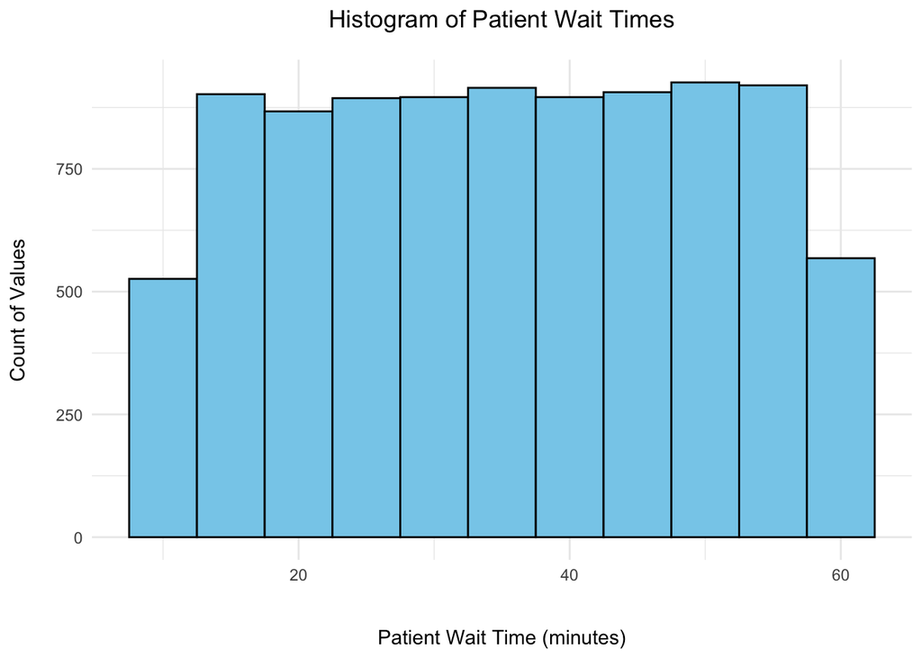

```r
ggplot(df, aes(x = patient_waittime)) +
  geom_histogram(binwidth = 5, fill = "skyblue", color = "black") +
  theme_minimal() +
  labs(
    title = "Histogram of Patient Wait Times",
    x = "Patient Wait Time (minutes)",
    y = "Count of Values"
  ) +
  theme(
    plot.title = element_text(hjust = 0.5, margin = margin(b = 15)),
    axis.title.x = element_text(margin = margin(t = 25)) ,
    axis.title.y = element_text(margin = margin(r = 15))
  )
```

```r
mean_wait = round(mean(df$patient_waittime, na.rm = TRUE), 2)
median_wait = round(median(df$patient_waittime, na.rm = TRUE), 2)
```

The average patient wait time is 35.26 mins.

The median patient wait time is 35 mins.

**Patient Satisfaction Score**

The following is a kernel density estimate plot that depicts the spread of data across the satisfaction scale

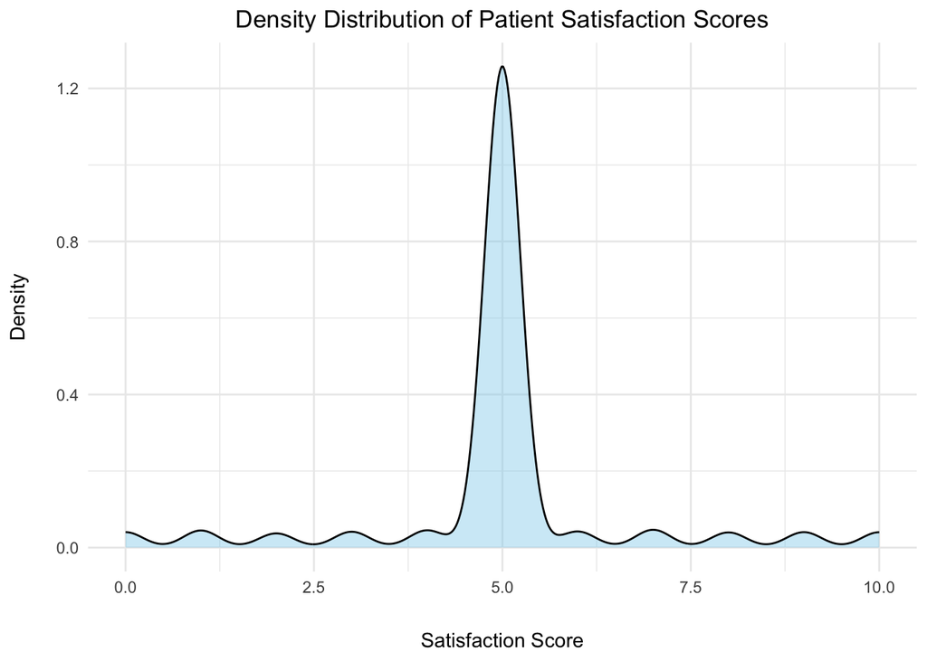

```r
ggplot(df, aes(x = patient_sat_score)) +
  geom_density(fill = "skyblue", alpha = 0.4) +
  theme_minimal() +
  labs(title = "Density Distribution of Patient Satisfaction Scores",
       x = "Satisfaction Score",
       y = "Density") +
  theme(
    plot.title = element_text(hjust = 0.5),
    axis.title.x = element_text(margin = margin(t = 20)),
    axis.title.y = element_text(margin = margin(r = 15))
  )
```

**The density plot shows a sharp peak near satisfaction score of 5, reaching a density of ~1.2. While this might seem high, the height of the density curve reflects how concentrated the data is at that point, and not the raw probability. The total area under the curve remains 1.**

**However, an important note to keep in mind is that we have imputed the median value for all missing values in the satisfaction score column so we expect majority values to cluster around the median. In order to do a more insightful analysis, we would need all raw scores to avoid needing to impute missing values.**

**Wait Time vs. Satisfaction Score Relationship**

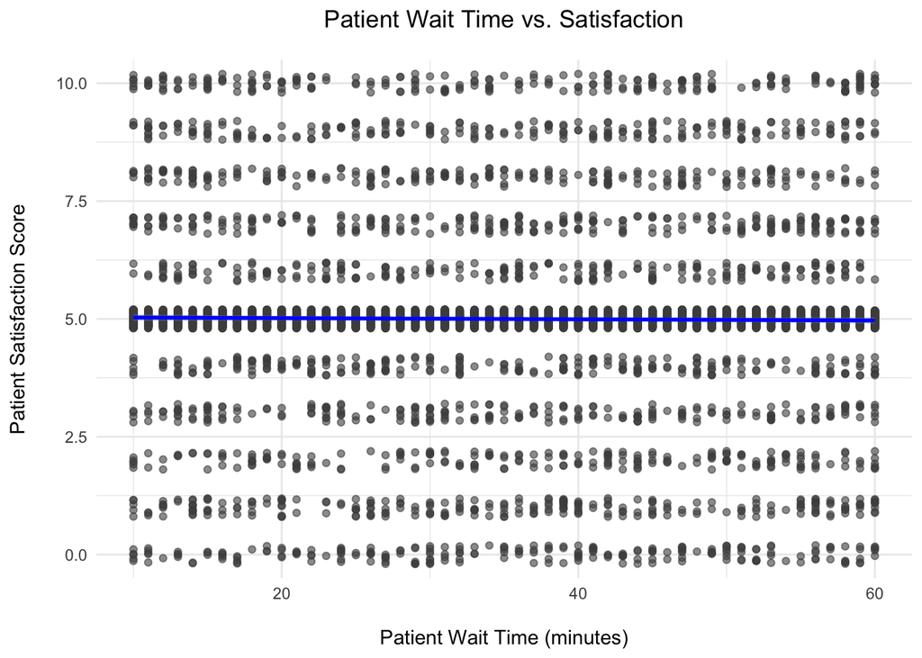

```r
ggplot(df, aes(x = patient_waittime, y = patient_sat_score)) +
  geom_jitter(width = 0, height = 0.2, alpha = 0.6, color = "gray30") +
  geom_smooth(method = "lm", se = TRUE, color = "blue") +
  coord_cartesian(ylim = c(0,10)) +
  theme_minimal() +
  labs(title = "Patient Wait Time vs. Satisfaction",
       x = "Patient Wait Time (minutes)",
       y = "Patient Satisfaction Score") +
  theme(plot.title = element_text(hjust = 0.5, margin = margin(b = 15)),
        axis.title.x = element_text(margin = margin(t = 15)),
        axis.title.y = element_text(margin = margin(r = 15)))
```

```r
corr = round(cor(df$patient_waittime, df$patient_sat_score), 2)
```

**Patient wait time and satisfaction score have a correlation of -0.01. This negative correlation aligns with intuition — as wait times increase, patient satisfaction tends to decrease. However, the magnitude of the correlation is extremely small (-0.01), indicating a very weak inverse relationship. This suggests that while wait time may play a role in shaping satisfaction, other factors are likely to have a much stronger influence on patient satisfaction scores.**

### Group Analysis

**Average Patient Wait Time By Day of the Week**

```r
weekday_summary = df %>%
  mutate(date = as_datetime(date),
        weekday = weekdays(date)) %>%
  group_by(weekday) %>%
  summarise(avg_wait = round(mean(patient_waittime, na.rm = TRUE), 2)) %>%
  arrange(avg_wait)
kable(weekday_summary)
```

| weekday | avg_wait |
| --- | --- |
| Saturday | 34.88 |
| Sunday | 35.08 |
| Thursday | 35.09 |
| Friday | 35.19 |
| Tuesday | 35.25 |
| Monday | 35.65 |
| Wednesday | 35.67 |

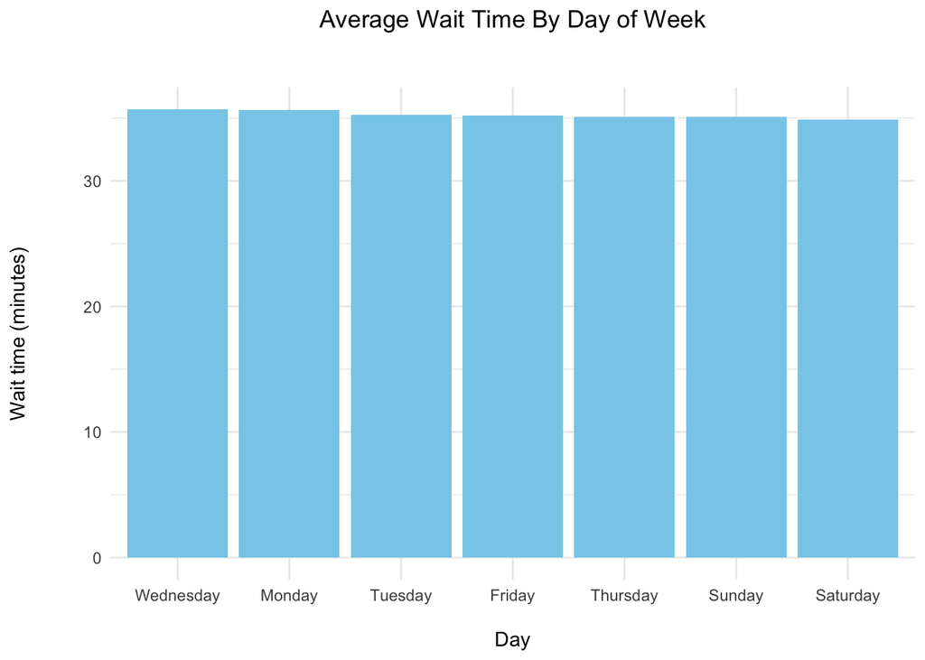

```r
ggplot(weekday_summary, aes(x = reorder(weekday, -avg_wait), y = avg_wait)) +
  geom_col(fill = "skyblue") +
  theme_minimal() +
  labs(title = "Average Wait Time By Day of Week", x = "Day", y = "Wait time (minutes)") +
  theme(
    plot.title = element_text(hjust = 0.5, margin = margin(b = 30)),
    axis.title.x = element_text(margin = margin(t = 15)),
    axis.title.y = element_text(margin = margin(r = 30))
  )
```

**Outlier Detection**

Outliers are a critical part of data analysis. If an outlier exists in the data it warrants further investigation because outliers significantly impact summary statistics of the data. For example, an outlier value that is far to the right from all other data points will significantly inflate the mean, standard deviation, and variance of the data. Therefore, it is important to further investigate if it is a true outlier or the result of human error via data entry.

Below we use a box plot to analyze patient wait time to detect any potential outliers. We are particularly interested in detecting any unusually high wait times.

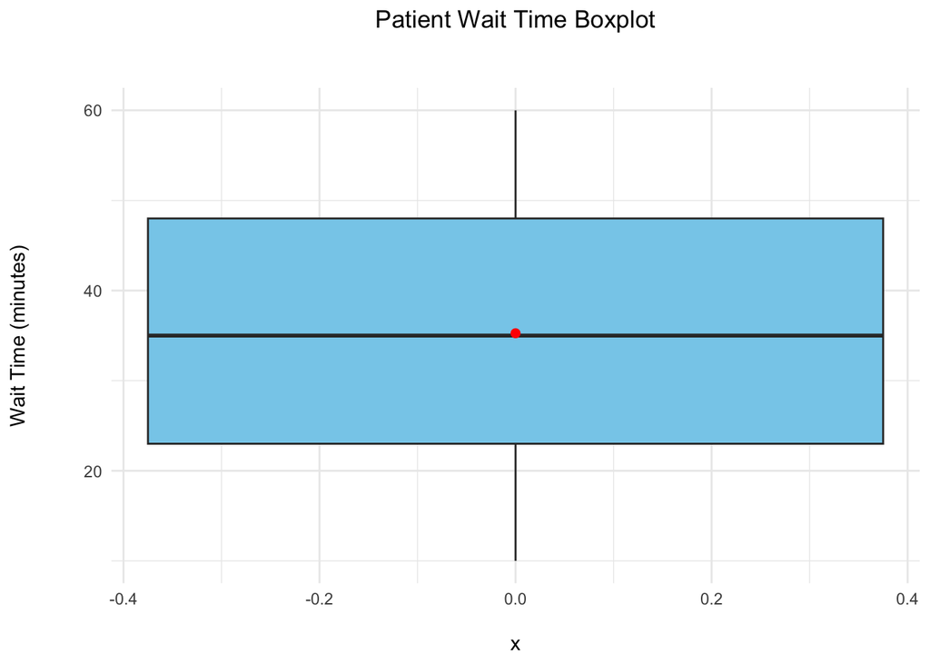

```r
ggplot(df, aes(x = 0, y = patient_waittime )) +
  geom_boxplot(fill = "skyblue") +
  stat_summary(fun = mean, geom = "point", shape = 20, size = 3, color = "red") +
  theme_minimal() +
  labs(title = "Patient Wait Time Boxplot",
       y = "Wait Time (minutes)") +
  theme(
    plot.title = element_text(hjust = 0.5, margin = margin(b = 30)),
    axis.title.x = element_text(margin = margin(t = 15)),
    axis.title.y = element_text(margin = margin(r = 30))
  )
```

**The boxplot above shows there are no outliers in our dataset.**

**Patient Wait Time By Race**

```r
df %>%
  group_by(patient_race) %>%
  summarise(avg_wait = round(mean(patient_waittime, na.rm = TRUE), 2)) %>%
  arrange(desc(avg_wait)) %>%
  kable()
```

| patient_race | avg_wait |
| --- | --- |
| Native American/Alaska Native | 35.69 |
| African American | 35.61 |
| Two or More Races | 35.36 |
| Asian | 35.27 |
| White | 35.11 |
| Declined to Identify | 34.94 |
| Pacific Islander | 34.65 |

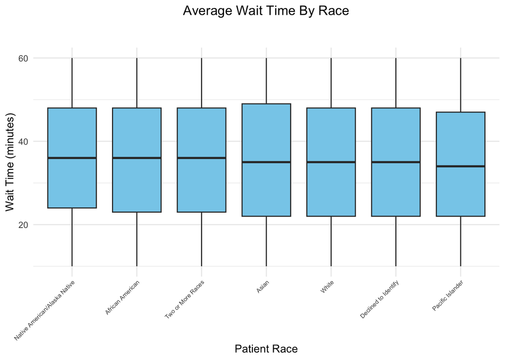

```r
ggplot(df, aes(x = reorder(patient_race, -patient_waittime, FUN = mean),
               y = patient_waittime)) +
  geom_boxplot(fill = "skyblue") +
  theme_minimal() +
  labs(title = "Average Wait Time By Race",
       x = "Patient Race",
       y = "Wait Time (minutes)") +
  theme(
    plot.title = element_text(hjust = 0.5, margin = margin(b = 30)),
    axis.text.x = element_text(angle = 45, hjust = 1, size = 6, margin = margin(t = 0)))
```

**Patient Wait Time by Age**

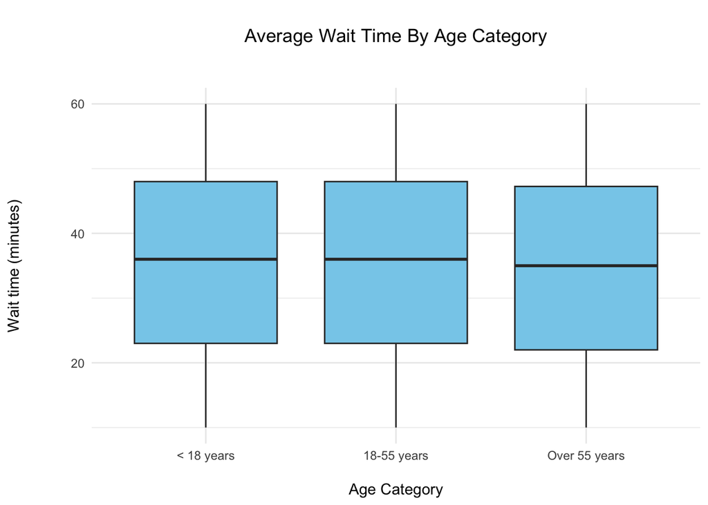

```r
df = df %>%
  mutate(age_category = case_when(
    patient_age < 18 ~ "< 18 years",
    patient_age >= 18 & patient_age <= 55 ~ "18-55 years",
    TRUE ~ "Over 55 years"
  ))

ggplot(df, aes(x = age_category, y = patient_waittime)) +
  geom_boxplot(fill = "skyblue") +
  theme_minimal() +
  labs(title = "Average Wait Time By Age Category", x = "Age Category", y = "Wait time (minutes)") +
  theme(
    plot.title = element_text(hjust = 0.5, margin = margin(b = 30, t = 15)),
    axis.text.x = element_text(hjust = 0.5),
    axis.title.x = element_text(margin = margin(t = 15)),
    axis.title.y = element_text(margin = margin(r = 35)))
```

**Patient Wait Time By Gender**

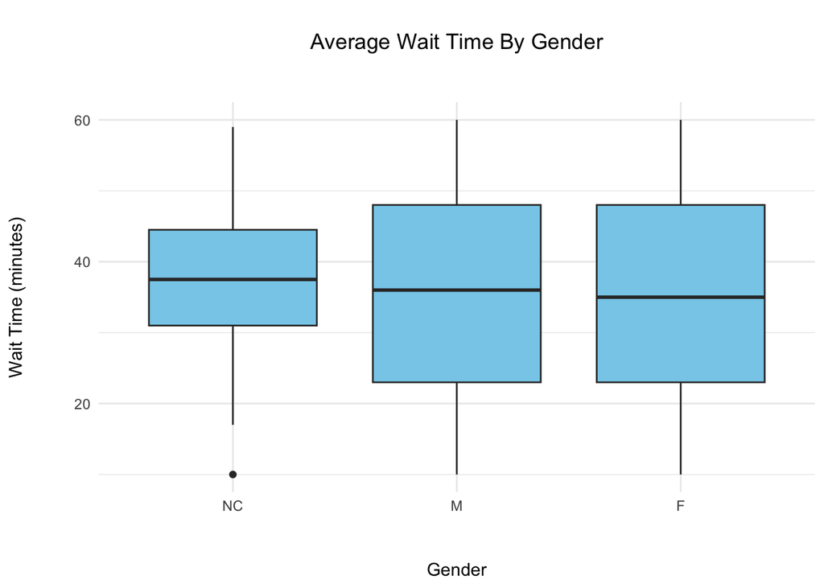

```r
ggplot(df, aes(x = reorder(patient_gender, -patient_waittime, FUN = mean), y = patient_waittime)) +
  geom_boxplot(fill = "skyblue") +
  theme_minimal() +
  labs(title = "Average Wait Time By Gender", x = "Gender", y = "Wait Time (minutes)") +
  theme(plot.title = element_text(hjust = 0.5, margin = margin(b = 30, t =15)),
        axis.title.x = element_text(margin = margin(t = 30)),
        axis.title.y = element_text(margin = margin(r = 30)))
```

**Patient Wait Time by Time of Day**

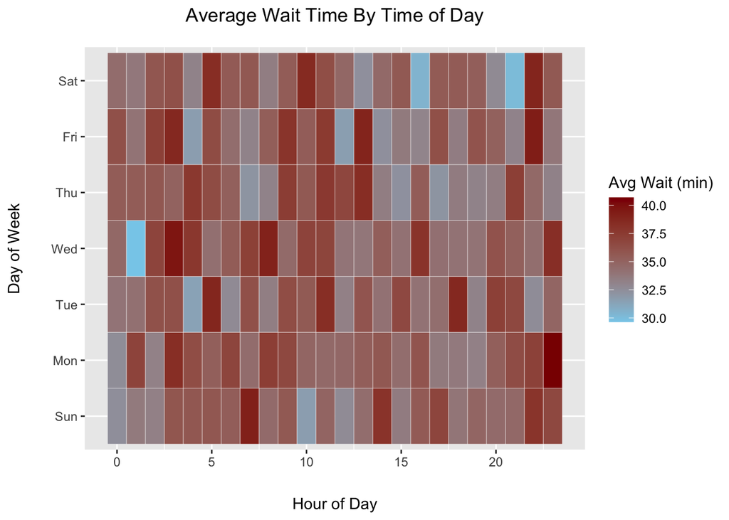

```r
# isolate hour and day of week for each record
df_heatmap = df %>%
  mutate(
    hour = as.integer( hour(df$date)),
    weekday = wday(df$date, label = TRUE, abbr = TRUE)
  ) %>%
  group_by(weekday, hour) %>%
  summarise(avg_wait = mean(patient_waittime, na.rm = TRUE), .groups = "drop")

ggplot(df_heatmap, aes(x = hour, y = weekday, fill = avg_wait)) +
  geom_tile(color = "white") +
  scale_fill_gradient(low = "skyblue", high = "darkred", name = "Avg Wait (min)") +
  labs(title = "Average Wait Time By Time of Day",
       x = "Hour of Day",
       y = "Day of Week") +
  theme(plot.title = element_text(hjust = 0.5, margin = margin(b = 15)),
        axis.title.x = element_text(margin = margin(t = 20)),
        axis.title.y = element_text(margin = margin(r = 20)))
```

The heatmap above visualizes average patient wait times across different hours of the day and days of the week. The x-axis represents the hour of the day (0–23), while the y-axis shows the day of the week. Each tile is color-coded to reflect the average wait time for that specific hour–weekday combination, with darker shades indicating longer wait times.

Notable patterns emerge from the visualization:

Slightly shorter wait times are generally seen during evening hours of 4-8p on Thursday, Friday, and Saturday.

These patterns may reflect operational factors such as staffing, patient inflow patterns, or seasonal trends.

This visualization helps identify temporal bottlenecks and can guide staffing or resource planning decisions in the emergency department.

**Average Wait Time Fluctuations Over Time**

[figure not shown]

```r
time_summary = df %>%
  mutate(month = as.Date(paste0(format(date, "%Y-%m"),"-01"))) %>%
  group_by(month) %>%
  summarise(avg_wait = mean(patient_waittime, na.rm = TRUE))

ggplot(time_summary, aes(x = month, y = avg_wait)) +
  geom_line(color = "steelblue") +
  scale_x_date(date_breaks = "2 month", date_labels = "%b-%Y") +
  theme_minimal() +
  labs(title = "Average Wait Time May 2019 - Sep 2020", x = "Date (Month-Year)", y = "Wait Time (minutes)") +
  theme(
    plot.title = element_text(hjust = 0.5),
    axis.title.y = element_text(margin = margin(r = 30)),
    axis.title.x = element_text(margin = margin(t = 15))
  )
```

### Conclusion

This exploratory analysis provides foundational insights into ER patient wait times and satisfaction, highlighting patterns, potential disparities, and areas for deeper analysis. Addressing data quality and incorporating additional variables will be key for more actionable conclusions.